# Python Lecture 3: I/O, System-Level, and Plotting

## Jarret Petrillo copyright 2020

## AMS 595

# Overview

## Inputs are:

1. command-line input.
2. direct user input.
3. file read input.

## Outputs are:

1. print output.
2. file output.
3. "pickled" objects.

## Systems-level mechanics are:

1. interacting with the filesystem.
2. manipulating filenames.

## Plotting:

# Part 1

1. Command-line input.
2. interacting with the filesystem.
3. manipulating filenames.

# ls.py

python ls.py filename

This script will check the current directory for a file named "filename."

Otherwise, it will print, "not found."

```python
# test.py

import sys

if __name__ == "__main__":
    print(sys.argv)
```

```python
# python test.py 2313 312 123

# ['test.py', '2313', '312', '123']
```

```python
type(sys.argv)
```

```python
# test2.py

import sys

if __name__ == "__main__":
    print([type(x) for x in sys.argv])
```

```python
# test2.py 231 23123 1

# [<class 'str'>, <class 'str'>, <class 'str'>, <class 'str'>]
```

```python
import os
help(os)
```

```python
os.listdir()
```

```python
3 in [1,2,3]
```

```python
# ls.py

import sys
import os

def search_filesystem(filename):
    if filename in os.listdir():
        print("found!")
    else:
        print("not found.")


if __name__ == "__main__":
    search_filesystem(sys.argv[-1])
```

# find_ext.py

python find_ext.py file_extension

This script will check the current directory for any files that end with extension "file_extension"

If one is there, print the first one.

Otherwise, it will print, "none found."

```python
# find_ext.py

import sys
import os

def search_filesystem(file_ext):
    for filename in os.listdir():
        if file_ext == os.path.splitext(filename)[-1]:
            print("found:", filename)
            break
    else:
        print("none found.")


if __name__ == "__main__":
    search_filesystem(sys.argv[-1])
```

```python
# python find_ext.py .ipynb

# found: iosystemplotting.ipynb
```

# Part 2

1. direct user input.

```python
# user_input.py

txt = input("Type something to test this out: ")
print("Did you say:",txt,"?")
```

# Part 3

1. pickled objects.
2. reading and writing to standard files.

# To Pickle (verb)

definition: to preserve or steep in brine or other liquid.

We will not use brine.

Python has a way to save objects so that they can be read back as *Python objects*.

```python
import pickle
from datetime import datetime

data_dict = dict(greeting="Hello, UserName",
                 last_login=datetime.fromisoformat("2018-02-01"),
                 number_posts=231)

data_dict
```

```
{'greeting': 'Hello, UserName',
 'last_login': datetime.datetime(2018, 2, 1, 0, 0),
 'number_posts': 231}
```

```python
with open("data_dict.pickle",'wb') as f:
    pickle.dump(data_dict, f)
```

```python
with open("data_dict.pickle",'rb') as f:
    object_from_filesystem = pickle.load(f)
object_from_filesystem
```

```
{'greeting': 'Hello, UserName',
 'last_login': datetime.datetime(2018, 2, 1, 0, 0),
 'number_posts': 231}
```

# Reading and writing to the filesystem

We saw two examples.

The key will be the *with* clause and *open* funtion.

With clauses manage the context of open and closing.

```python
with open("new.csv", "w") as f:
    f.write("1,1,1,1\n")
    f.write("2,1,1,1\n")

with open("new.csv", "r") as f:
    for line in f:
        print(line)
```

```
1,1,1,1

2,1,1,1
```

# Part 4

1. Make a plot.
2. Save a plot as a file.

```python
import matplotlib.pyplot as plt
```

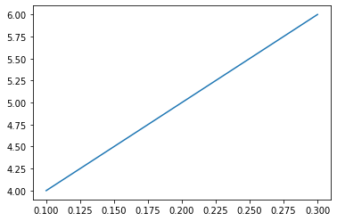

```python
plt.plot([0.1,0.2,0.3],[4,5,6])
```

```python
plt.clf() # clears plot
```

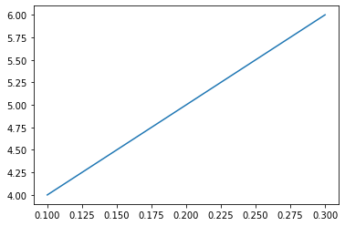

```python
plt.plot([0.1,0.2,0.3],[4,5,6])
plt.savefig("line_graph.png")
```